# Sesión 2.1 Instalación y configuración de infraestructura software para la Web

Ingeniería de Servicios

2023-2024

# 1 Introducción

En esta práctica se va a instalar y configurar un conjunto de herramientas que sirvan para proporcionar soporte a las aplicaciones y a los servicios web. Esta infraestructura software se instalará sobre el servidor Linux de prácticas y constará de los siguientes servicios: servidor Web, servidor cgi para la gestión de contenido dinámico, y base de datos. Cada uno de ellos será un contenedor docker, adecuadamente configurado.

# 2 Servidor Web

Un servidor Web es un servicio que sirve contenido Web mediante el protocolo HTTP. Generalmente un servidor Web funciona como una aplicación que se ejecuta sobre el sistema operativo, aunque en ciertos casos también se puede integrar en el kernel del operativo. Lo más habitual es que el servidor Web sea una aplicación ya que proporciona un nivel de seguridad y modularidad mucho mayor.

A la hora de elegir un servidor Web hay muchas opciones. Los más comunes son el servidor Apache, el Microsoft IIS (*Internet Information Services*), previamente conocido como *Internet Information Server*, y el Nginx (pronunciado *engine-x*). El IIS sólo funciona sobre Windows, y está fundamentalmente diseñado para trabajar conjuntamente con el resto de herramientas de Microsoft, como el SQL Server o ASP.NET. Puedes consultar el estado de la [cuota de mercado](http://w3techs.com/technologies/cross/web_server/ranking) de cada servidor.

Apache y Nginx tienen un diseño completamente diferente. La versión más común de Apache se basa en un modelo de concurrencia por proceso. Cuando recibe una petición clona un proceso para que atienda a esa petición. Nginx se basa en un modelo de concurrencia basado en eventos. Bajo este modelo, un conjunto de procesos pre-creados se encarga de gestionar todas las peticiones de los clientes. Por tanto, un solo proceso va a gestionar múltiples conexiones mediante eventos asociados a cada una de ellas[^1]. Cuando el servidor Web tiene un uso bajo o medio ambos servidores tiene un comportamiento similar. Sin embargo, cuando el número de clientes es elevado el modelo usado por Apache es mucho más ineficiente, tanto en uso de recursos (CPU, memoria) como en productividad (número de peticiones servidas por segundo). Esto hace que para servidores con gran utilización se tienda a instalar Nginx. Por ejemplo, Nginx es claramente el servidor más utilizado entre los 1000 sitios Web más de más uso. En estas prácticas se trabajará con el servidor Nginx.

## 2.1 Instalación de Nginx

Nginx puede instalarse por el método clásico (`apt install`), y en ese caso sus archivos de configuración estarán en `/etc/nginx`. Por defecto, en Ubuntu, los archivos de configuración que vienen esperan que las páginas web a servir por nginx estén en la carpeta `/var/www/html`, y nginx quedaría escuchando en el puerto 80 de nuestro servidor Ubuntu. Modificar los ficheros de configuración requiere permisos de administrador. Lanzar el propio servidor `nginx`, detenerlo, reiniciarlo, etc. también requiere permisos de administrador y el conocimiento de cómo se lanzan servicios en Ubuntu.

Si queremos asegurarnos de tener la última versión podríamos instalarlo desde su código fuente, haciendo la compilación nosotros mismos. Esto suele ser engorroso.

Otra posibilidad es lanzarlo dentro de un contenedor usando `docker`. En este caso, suponiendo que tengamos una imagen preparada y configurada correctamente, al lanzar esa imagen se crearía un contenedor dentro del cual estaría escuchando nginx, en el puerto 80. A menos que mapeemos con la opción `-p` (ver práctica sobre TCP) ese puerto del contenedor a otro puerto del anfitrión, el servidor no podrá ser contactado desde fuera, lo que en algunos escenarios podría ser útil. Lo mejor de esta segunda opción es que nginx seguirá buscando su configuración dentro de la carpeta `/etc/nginx`, pero en este caso se trata de una carpeta del contenedor, que podemos sustituir por una propia montándola como un volúmen mediante la opción `-v`. Esto hace más sencillo modificar la configuración e incluso mantenerla bajo control de versiones en nuestar propia carpeta de usuario.

Veremos ambos enfoques, si bien posteriormente nos quedaremos sólo con la versión que se ejecuta dentro de un contenedor.

### 2.1.1 Instalación con apt

Antes de instalar nada, comprueba qué puertos TCP tiene abiertos nuestra máquina mediante el comando:

```bash
$ sudo netstat -4tln
```

Ya que no hemos instalado aún el servidor web, el puerto 80 no debería aparecer en la lista. Aparecerá en cambio el puerto 22, que es el estándar para SSH, y probablemente el 53 utilizado para DNS (veremos estos servicios en prácticas futuras)

Mediante `sudo netstat -4tan` podrías ver no sólo los sockets de escucha, sino también los de datos y por tanto todas las conexiones que en ese momento tiene abiertas la máquina. Si quieres saber qué programas son los que están usando esas conexiones puedes añadir la opción `-p`, o usar el comando `sudo lsof -i4 -n -P`

Instala ahora nginx con el comando

```bash
$ sudo apt install nginx
```

Verás que durante el proceso de instalación el gestor de paquetes detecta varias dependencias y las instala también.

Tras la instalación comprueba la versión instalada. Este comando también mostrará los módulos con los que el programa fue compilado.

```bash
$ nginx -V
```

Visita [la página web de nginx](http://nginx.org/) y comprueba la última versión estable disponible. Podrás comprobar que la versión instalada es más antigua ya que los paquetes de la distribución no se actualizan cada vez que hay una nueva versión de un paquete.

Comprueba que el servicio está en ejecución comprobando nuevamente las conexiones activas. También puedes ver el estado del servicio con `systemctl status nginx`, lo que te permitirá además leer los mensajes de error que se hayan producido si algo fue mal.

Deberías ver a Nginx escuchando conexiones en el puerto del protocolo HTTP (80). En este momento ya está funcionando el servidor Web con una configuración por defecto.

Abre un navegador Web y escribe la dirección IP del servidor donde has instalado el servicio. Debería aparecer una pantalla parecida a la siguiente.

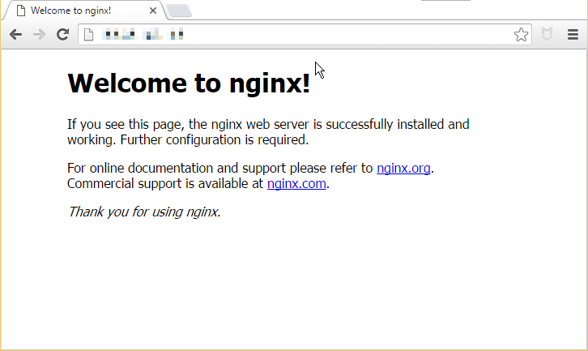

- `/usr/share/nginx/html/` Contiene habitualmente los ficheros que va a servir el servidor, depende de la distribución Linux.
- `/var/www/html/` Contiene en otros casos los ficheros que va a servir el servidor, según la distribución de Linux.
- `/etc/nginx/` Contiene la configuración del servidor.
- `/var/log/nginx/` Contiene los logs del servidor.

Averigua cuál de las dos posibles localizaciones para los ficheros del servidor es la que usa esta distribución de Linux. Para ello edita el fichero `index.html` instalado por defecto en cada una de esas localizaciones y realiza algún cambio. Ahora abre el navegador y verifica que se muestran los cambios. Para un servicio que simplemente necesite servir contenido estático la configuración por defecto sería suficiente.

Observa el fichero de log (`access.log`) donde han quedado anotadas las peticiones al servidor. Debería haber varias peticiones tipo `GET` con la información del agente del navegador que las realizó.

### 2.1.2 Instalación con docker

Para usar nginx en un contenedor ¡no necesitamos tener instalado nginx! (pues la imagen docker que descarguemos ya contendrá un binario de nginx, y seguramente en diferentes versiones para que podamos elegir una en concreto, probablemente más reciente que la disponible con `apt get`).

De modo que podemos desinstalar el que habíamos instalado en el punto anterior:

Detén nginx y desinstálalo con los comandos siguientes:

```bash
$ sudo systemctl stop nginx
$ sudo apt remove nginx
```

Desinstala el resto de paquetes que se habían instalado como dependencias de nginx y que ya no son necesarios:

```bash
$ sudo apt autoremove
```

Verifica con `netstat` que nadie escucha ya en el puerto 80, y que al recargar la página que veías en el navegador se obtiene un error porque el servidor ya no responde.

Una vez estamos seguros de que ya no tenemos nginx en el sistema, descarguemos una versión con docker. En general, cada aplicación instalable via docker existe en múltiples imágenes, preparadas por la comunidad de usuarios de docker. Es típico tener una imagen diferente por cada versión de la aplicación, para elegir la que necesitemos en un momento dado. El tag `latest` significa la última disponible. A veces también hay variantes de la misma aplicación en diferentes imágenes que se diferencian en qué otras utilidades vienen instaladas en la imagen.

Instalaremos la versión oficial de nginx en su última versión, mediante el comando:

```bash
$ docker pull nginx
```

Utiliza el comando `docker images` para averiguar cuánto ocupa la imagen descargada. Como ves es mucho más pequeña que las imágenes con python que habíamos descargado en sesiones anteriores. Ello se debe a que la imagen de `nginx` sólo contiene el servidor, binario, mientras que las de python incluían muchas herramientas de desarrollo y bibliotecas.

Ahora lancemos un contenedor con esa imagen (observa la opción `-d` para que se desconecte de la terminal y continúe en segundo plano).

```bash
$ docker run -d --rm --network pruebas --name nginx nginx
```

¿Qué significan las diferenets opciones que le hemos pasado? ¿Las recuerdas? Consulta la documentación de prácticas anteriores, o usa `docker run --help`, o pregunta a tu profesor

Aparentemente `nginx` se está ejecutando. Comprueba con `docker ps` que el contenedor está en funcionamiento. ¿En qué puerto está escuchando `nginx`?

Ahora bien, ¿qué ves si haces `netstat -4tpl`? ¿Ves alguien escuchando en el puerto 80? ¿Por qué?

Lo que ocurre es que `nginx` escucha en el puerto 80 *del contenedor*, no de la máquina anfitrión. Para conectar con esa instancia de nginx debemos conectarnos con la IP del contenedor.

Averigua la IP del contenedor (con `docker inspect nginx`) y utiliza la herramienta de línea de comandos `wget` para conectarte con el servidor web y descargar su respuesta así:

```bash
$ wget <ip-que-has-averiguado>
```

Por defecto `wget` conectará al puerto 80 de la IP especificada, y solicitará la ruta `GET /`, ante lo cual, si todo va bien, el servidor nginx responderá con el archivo `index.html`

Comprueba que recibes un `index.html` con la página por defecto suministrada por nginx.

Esta versión de `nginx` que se ejecuta en el contenedor sólo tiene dos ficheros que puedas solicitarle, uno es el `index.html` que acabas de obtener, el otro es uno llamado `50x.html` que necesitaremos luego, de modo que obtenlo también con:

```bash
$ wget <ip-que-has-averiguado>/50x.html
```

### 2.1.3 Despliegue más flexible

El contenedor ejecutando nginx ha funcionado, pero no tenemos forma de contactar con el servidor web desde fuera de la máquina Linux, pues la IP que has averiguado en el último experimento es una IP privada, no visible desde el exterior.

Por otro lado tampoco podemos modificar la página que el servidor devuelve, o añadir contenidos nuevos, ya que esa página está dentro del contenedor, y aún si consiguiéramos cambiarla, el cambio no sería persistente.

Vamos a arreglar ambos aspectos, pero antes necesitamos saber en qué carpeta del contenedor espera nginx encontrar los archivos a servir. Para ello:

Entra en el contenedor que está en ejecución por el método de lanzar un segundo proceso dentro del contenedor, con `docker exec`, así:

```bash
$ docker exec -it nginx bash
```

Una vez dentro del contenedor ve a la carpeta `/etc/nginx/conf.d` y examina el fichero `default.conf` (puedes usar el comando `more`) y has de ver lo siguiente:

```
server {
    listen       80;
    server_name  localhost;

    #charset koi8-r;
    #access_log  /var/log/nginx/host.access.log  main;

    location / {
        root   /usr/share/nginx/html;
        index  index.html index.htm;
    }

    #error_page  404              /404.html;

    # redirect server error pages to the static page /50x.html
    #
    error_page   500 502 503 504  /50x.html;
    location = /50x.html {
        root   /usr/share/nginx/html;
    }

    # proxy the PHP scripts to Apache listening on 127.0.0.1:80
    #
    #location ~ \.php$ {
    #    proxy_pass   http://127.0.0.1;
    #}

    # pass the PHP scripts to FastCGI server listening on 127.0.0.1:9000
    #
    #location ~ \.php$ {
    #    root           html;
    #    fastcgi_pass   127.0.0.1:9000;
    #    fastcgi_index  index.php;
    #    fastcgi_param  SCRIPT_FILENAME  /scripts$fastcgi_script_name;
    #    include        fastcgi_params;
    #}

    # deny access to .htaccess files, if Apache's document root
    # concurs with nginx's one
    #
    #location ~ /\.ht {
    #    deny  all;
    #}
}
```

Más adelante daremos detalles de qué significan estas líneas, pero de momento fijémonos en la que dice `root`. Su valor es `/usr/share/nginx/html` y esa es la carpeta (dentro del contenedor) donde `nginx` espera encontrar los archivos que los clientes le pidan. Comprobarás que no usa la misma configuración que vimos cuando lo instalamos en Ubuntu con `apt install`.

Ahora podemos lanzar de nuevo `nginx` con las opciones necesarias para que sirva nuestros propios ficheros (en lugar de el que servía por defecto) y además sea visible desde fuera.

1. Termina el contenedor donde teníamos ejecutándose a nginx (`docker stop`)
2. Crea una carpeta (dentro de la que usas en esta sesión de prácticas) llamada `html` y copia a ella los ficheros `index.html` y `50x.html` que descargaste antes con `wget`.
3. Entra en esa carpeta (`cd html`)
4. Lanza de nuevo la imagen `nginx` pero esta vez pásale las opciones adicionales `-p 80:80` y `-v $(pwd):/usr/share/nginx/html` ¿Para qué son estas opciones? Si no lo recuerdas pregunta a tu profesor.
5. Conecta un navegador web a la IP de tu Linux y comprueba que obtienes respuesta.
6. Modifica el fichero `index.html` y recarga la página, para comprobar que se ven las modificaciones.

Los logs de este nginx *conteinerizado* los vuelca también a `/var/log/nginx/acces.log`, pero es una ruta dentro del contenedor, que está configurada de modo que está conectada con la salida estándar. Por tanto es como si `nginx` contuviera órdenes `print` para ir mostrando en la salida estándar la información de las conexiones que recibe. No obstante no se ve nada en la terminal porque lo hemos lanzado en modo `-d`, lo que implica que su salida estándar está desconectada de la terminal. ¿Dónde está entonces el log de nginx?

Lo que ocurre es que docker va guardando la salida estándar de los contenedores lanzados en modo `-d`, para que podamos examinarla en cualquier momento si es necesario. El comando `docker logs` sirve para esto.

Usa `docker logs nginx` para ver los logs de ese contenedor y comprueba que aparecen las peticiones que hiciste desde el navegador.

## 2.2 Configuración básica

En la primera instalación que hicimos por el método `apt install nginx`, la carpeta de configuración de nginx era `/etc/nginx` dentro de la máquina Linux. En cambio, al lanzarlo en un contenedor, la configuración la buscará dentro de `/etc/nginx` del contenedor como ya vimos antes.

La configuración de `nginx` es un tema complejo, pues es altamente configurable (permite especificar el número de procesos trabajadores, los tipos MIME, el usuario bajo el cual se ejecutarán sus procesos, el formato del archivo de log y otros muchas opciones de bajo nivel). Todas esas opciones están repartidas en diferentes ficheros dentro de `/etc/nginx`. Explicarlas todas se sale de los objetivos de la asignatura.

Sin embargo, las opciones con las que ya viene preconfigurado, son adecuadas para la mayoría de las situaciones y lo único que podríamos querer cambiar es la configuración de cada “sitio” que es servido por nginx (un “sitio” es una dirección web que tiene asociados unos certificados si usamos https, y una carpeta donde están los contenidos, así como unos protocolos para ejecutar aplicaciones por CGI, FastCGI o WSGI). Un “sitio” también se denomina *virtual host*.

Estas configuraciones específicas de un sitio se guardan en forma de varios ficheros (uno por “sitio”) en la carpeta `/etc/nginx/conf.d` (aunque esto depende de cómo haya sido instalado y configurado, esta explicación se refiere a la versión *dockerizada*). Por defecto trae un solo archivo en esa carpeta, que es el `default.conf` antes visto.

Si queremos cambiar detalles de la configuración del sitio tendremos que usar el mismo truco usado para cambiar `index.html`, es decir, tener una copia del archivo `default.conf` en una carpeta local del anfitrión y montar esa carpeta en el lugar adecuado del contenedor para que nginx vea allí lo que espera.

1. Sal de la carpeta `html` donde teníamos el `index.html`
2. Crea una nueva carpeta que llamarás `sitios_nginx`
3. Entra en esa carpeta y crea un fichero llamado `default.conf` cuyo contenido copiarás del que hemos listado más arriba.

Si observas con un poco de detalle este contenido, verás que la mayoría está comentado y puede servirte de guía si quieres activar opciones distintas de las que usa por defecto.

La estructura básica es:

```
server {
    opciones generales;

    location / {
        opciones que se aplican a la ruta /
        (bloques similares pueden hacerse para otras rutas)
    }
    opciones para páginas de error;
}
```

La sección `server` contiene la configuración del *virtual host*. En las opciones generales aparece la directiva `listen`, que indica donde debe escuchar el servidor. Si no se le pone esta directiva, por defecto escucha en el puerto 80 de todas las interfaces de red (del contenedor). La directiva `server_name` es para indicar el nombre del servidor. Es para cuando dicho nombre está registrado en un DNS (es decir, tenemos un nombre como `mi.servidor.com` apuntando a la IP de la máquina), y especialmente útil cuando la misma IP tiene diferentes nombres (porque aloja varios servidores), de este modo es posible configurar cada uno por separado. En nuestro caso que no tenemos DNS podemos dejar `localhost`.

La directiva `location` va seguida de una expresión que encaja con una ruta o varias (cuando contiene asteriscos). La ruta `/` representa “peticiones dirigidas a la raiz del servidor” e incluye también las dirigidas a cualquier subcarpeta de la raiz, a menos que otras directivas `location` proporcionen otras reglas para sub-rutas específicas. La directiva `location` puede usarse también para configurar qué debe hacer el servidor cuando se le piden archivos con ciertas extensiones, como `.php`, y en este caso se le puede indicar que contacte con un servidor cgi (FastCGI, wsgi, etc.) para que sea ese servidor quien ejecute el script.

En la configuración por defecto se define tan solo una ruta raíz, y se proporcionan ejemplos (comentados) de cómo definir otras rutas.

Dentro de `location`, la directiva `root` indica el lugar donde se almacenan los ficheros del sitio web. La directiva `index` indica el fichero a servir si la petición hace referencia a un directorio y no a un fichero. Puede haber varios ficheros que se intentan servir según el orden que se indica. Si no hay uno se sirve el siguiente, etc. Examina la configuración por defecto para esta directiva. Asegúrate de que comprendes por qué, al acceder simplemente a la IP de la máquina desde un navegador, se mostraba el fichero que se mostraba (`/usr/share/nginx/htnml/index.html`).

Hay muchas directivas que se pueden incluir dentro de `location`. Por ejemplo `try_files` sirve para indicar cómo servir los ficheros. Un posible valor puede ser el siguiente:

```
try_files $uri $uri/ /index.html;
```

Esto le indica que primero pruebe a buscar el nombre del fichero exacto, luego tratarlo como si fuera un directorio (añadirle una barra al final) y por último si no existe servir el fichero `/index.html`. Otra opción es mostrar un mensaje de error como última opción. Para ello habría que cambiar el valor de la directiva de la siguiente forma:

```
try_files $uri $uri/ =404;
```

Vamos a probar una de estas opciones.

1. Edita el fichero `default.conf` que tienes en `sitios_nginx` y añade la línea anterior dentro del grupo `location /`
2. Detén el contenedor `nginx` si lo tenías funcionando (`nginx stop`)
3. Sube un nivel en las carpetas de modo que estés en la que contiene `html` y `sitios_nginx` como subcarpetas.
4. Desde esta carpeta lanza de nuevo el contenedor nginx con el siguiente comando.

   ```bash
   $ docker run --rm -d --network pruebas \
      --name nginx -p 80:80 \
      -v $(pwd)/html:/usr/share/nginx/html \
      -v $(pwd)/sitios_nginx:/etc/nginx/conf.d nginx
   ```

   Fíjate que estamos montando ahora dos volúmenes; uno que contiene como antes los ficheros html a servir y otro que contiene la configuración. Si no entiendes alguna opción pregúntale al profesor. Puedes copiar el comando anterior en un *shell script* para no tener que teclearlo cada vez que haya que lanzar nginx en sucesivos experimentos.
5. Comprueba que el navegador sigue accediendo correctamente al sitio y prueba también a solicitarle un fichero que no existe.

**Ejercicio1**

Escribe, dentro de la carpeta `sitios_nginx` un segundo fichero de configuración que llamarás `sitio2.conf`. Usa `default.conf` como punto de partida, pero modifícalo para que el sitio 2 tenga como directorio raíz `/usr/share/nginx/html2/` y escuche en el puerto `81`. Añade un fichero `index.html` distinto a ese sitio.

Escribe un shell script para lanzar nginx en un contenedor. Será como el que usaste la última vez, pero con un volumen adicional para acceder al html del segundo sitio (no hace falta un volumen adicional para el segundo fichero `.conf`, pues ambos están la misma carpeta). También tendrás que mapear el puerto 81 del contenedor en el puerto 81 del anfitrión, para poder probarlo desde fuera.

Conecta el navegador web a la IP de linux y comprueba que se sigue viendo correctamente la página que ya veíamos desde el principio. Después conéctalo a la misma IP, puerto 81, y comprueba que ahora se ve la que pusiste en `html2`.

Guarda bajo control de versiones los contenidos de esta carpeta y sus subcarpetas (es decir, los ficheros html, los de configuración y los scripts de lanzamiento).

## 2.3 Seguridad (opcional)

Antes de hacer a un servidor visible en Internet conviene ajustar ciertos parámetros. El primero de ellos tiene que ver con la información que da el servidor de sí mismo. Por ejemplo, cuando se intentar cargar una página que no existe el servidor indica en la parte inferior qué versión se está ejecutando.

[figure not shown]

Esta información podría servir a un atacante para buscar *exploits* específicos para una versión concreta. Lo que hace mucho más fácil el ataque.

Para minimizar riesgos hay una serie de opciones de configuración de nginx que podríamos tocar. El problema es que estos cambios deben hacerse en el fichero global `/etc/nginx/nginx.conf` (dentro del contenedor) y no en las configuraciones de los sitios que es lo que habíamos estado haciendo hasta ahora.

No es muy complicado de todas formas, pero se deja esta parte como opcional. Tendrías que:

1. Sacar una copia del fichero `nginx.conf` que está dentro del contenedor y dejarla en una carpeta, por ejemplo en `configuracion_nginx` (hermana de `sitios_nginx`). Para sacar copias de ficheros que están dentro de contenedores disponemos del comando `docker cp`. Así:

   ```bash
   $ docker cp nginx:/etc/nginx/nginx.conf configuracion_nginx/nginx.conf
   ```

2. Editar la copia que acabamos de extraer, para añadirle las siguientes opciones, dentro del bloque `http`:

   ```
   server_tokens off;  # Evita que se muestre la versión de nginx

   # Límites a tamaños y tiempos para minimizar ataques DOS
   client_max_body_size  4096k;
   client_header_timeout 10;
   client_body_timeout   10;
   keepalive_timeout     10; # Cuidado, este ya existía en el fichero con otro valor
                             # Eliminar el anterior o no arrancará
   send_timeout          10;
   ```

La directiva `client_max_body_size` establece el tamaño máximo de archivo que un usuario puede subir al servidor. `client_header_timeout` establece el tiempo máximo (en segundos) que el servidor va a esperar a recibir la cabecera del cliente y `client_body_timeout` el tiempo hasta que el cliente pide un fichero. `keepalive_timeout` especifica que el servidor debe abrir una conexión `keep-alive` como mucho durante ese tiempo. `send_timeout` establece el tiempo máximo que el servidor va a esperar a cerrar una conexión si el cliente no recibe datos.

Hay [muchas más directivas](https://nginx.org/en/docs/http/ngx_http_core_module.html) que se pueden configurar para adecuar el comportamiento del servidor a las necesidades concretas.

El siguiente aspecto a tener en cuenta respecto a la configuración de la seguridad del servidor sería el HTTPS. El HTTPS tiene varios objetivos. Uno de ellos consiste en cifrar la información que se transmite, para que nadie excepto el servidor y el cliente sean capaces de interpretar los datos. También permite la autenticación del sitio Web al que el cliente se conecta, es decir, que el cliente pueda verificar que el servidor es en realidad quien dice ser y no un sitio de *phising*.

Para poder configurar el HTTPS hay que obtener un certificado. Generalmente para hacer pruebas se auto genera un certificado. Sin embargo, en sitios reales los certificados los emite una autoridad certificadora. De esta forma el cliente, que confía en la autoridad certificadora, tiene la seguridad de que el servidor es quien dice ser. El certificado se debe asociar a un dominio, es decir, a un nombre en Internet. En la mayoría de los casos las autoridades certificadoras cobran por certificados y por su renovación.

En esta práctica la configuración de no se contempla, ya que se verá en la asignatura de seguridad.

# 3 Gestión del contenido dinámico

En un origen los servidores Web servían contenido estático (es decir, archivos que estaban ya escritos y almacenados en carpetas, como el `index.html` ya visto). Sin embargo, con el tiempo se observó que la versatilidad de este tipo de servidores venía derivada de la gestión del contenido dinámico que permite ejecutar programas en el servidor para servir un contenido que puede cambiar cada vez, según la hora del día, o el cliente, o los parámetros enviados. El código que se ejecuta en el servidor se puede realizar en prácticamente cualquier lenguaje de programación. Sin embargo, hay algunos lenguajes que se han popularizado dada su facilidad para crear cierto tipo de aplicaciones. Los más frecuentemente utilizados son PHP, C#, Java, Node.js y Python.

Si nos centramos en los lenguajes interpretados (PHP, Node.js y Python) para poder ejecutar código en estos lenguajes necesitamos obviamente los intérpretes correspondientes, y un mecanismo para “conectar” estos intérpretes con nginx. El mecanismo debe permitir a nginx indicar a los intérpretes qué script ejecutar, y poder pasarles los parámetros recibidos desde el cliente http (la url solicitada, las cabeceras de la petición, etc.) así como recibir una respuesta del script para que nginx pueda añadirle las cabeceras adecuadas y devolvérsela al cliente usando el protocolo HTTP. Si el script que se va a ejecutar incluye él mismo bibliotecas para manejar directamente el protocolo HTTP, entonces nginx simplemente le reenvía la petición del cliente tal cual, actuando como un proxy reverso.

Los mecanismos más habituales que puede utilizar nginx para esta tarea son, entre otros: proxy_http, FastCGI y WSGI. Cuál de ellos usar depende bastante del lenguaje de scripting que utilice la aplicación dinámica que será invocada. Si la aplicación “habla” http, se puede usar directamente proxy_http (este es el caso de nodejs y puede usarse también con python). Si no puede (o por motivos de eficiencia prefiere delegar en nginx el manejo del protocolo HTTP), típicamente se usará entonces FastCGI (por ejempo con PHP) o wsgi (específico de python).

Haremos un ejemplo mínimo con Python, inicialmente usando un servidor web que forme parte de la aplicación python (durante el desarrollo), para pasar después a desplegarlo en un contenedor que use wsgi y esté conectado con el contenedor de nginx via proxy_http, para lo que nginx ha de estar debidamente configurado.

## 3.1 Instalación de un framework (Flask)

Python tiene varios *frameworks* muy utilizados para el desarrollo de aplicaciones web. Uno muy popular es [Django](https://www.djangoproject.com/) (usado por ejemplo por Pinterest, Instagram, Bitbucket, Prezi y otros). Django es muy completo y trae incluidos mecanismos y soluciones para los componentes más típicos de una web (conectores con bases de datos, mecanismos de migración, etc.) No obstante para proyectos pequeños que no requieran toda esa infrastructura o que se alejen del esquema clásico, suele utilizarse mucho [Flask](http://flask.pocoo.org/), especialmente útil para construir microservicios con API REST (es utilizado internamente por Netflix, Reddit, el MIT, y otras muchas *start-ups* menos conocidas).

En esta asignatura usaremos Flask.

Para desarrollar y probar nuestra aplicación, usaremos el python que viene instalado en Ubuntu. Más adelante crearemos un contenedor con Flask para ejecutarla en producción.

Necesitaremos instalar paquetes python pero no queremos hacerlo globalmente para no “contaminar” las carpetas del sistema con paquetes específicos de ciertas aplicaciones. Por ello usaremos *entornos virtuales* que no son más que carpetas que se comportan como si fueran instalaciones python completas, pero que pertenecen al usuario y no interfieren unas con otras.

Para usar los entornos virtuales en Ubuntu es necesario instalar antes el módulo `venv`, que habitualmente es parte de Python3, pero por alguna razón los desarrolladores de Ubuntu decidieron no incluir por defecto.

Ejecuta los comandos siguientes:

```bash
$ sudo add-apt-repository universe
$ sudo apt install python3-venv
```

Ahora ya podemos crear el entorno virtual en el que instalar Flask:

1. Crea un entorno virtual en el que instalaremos Flask, para no tener que instalarlo a nivel global en el sistema. La carpeta en que se instalará todo será `~/flaskenv` (esta carpeta no necesita estar bajo control de versiones):

   ```bash
   $ python3 -m venv ~/flaskenv
   ```

2. Activa el entorno virtual (comprueba que el prompt cambiará y pondrá entre paréntesis el nombre de ese entorno):

   ```bash
   $ source ~/flaskenv/bin/activate
   (flaskenv) $
   ```

3. Con el entorno virtual activado podemos instalar paquetes python utilizando `pip install <nombre-del-paquete>`, y la instalación ocurrirá en la carpeta `~/flaskenv` sin afectar al resto del sistema. Podemos crear más entornos virtuales del mismo modo e instalar cosas diferentes en cada uno. Al activar un entorno virtual, el python que se usará será el que está en esa carpeta y tendrá accesibles todos los paquetes instalados en ella.

   ```bash
   (flaskenv)$ pip install wheel
   (flaskenv)$ pip install flask
   ```

   El paquete `wheel` es necesario para instalar otros paquetes que deban ser reconstruídos (compilado) durante su instalación. Normalmente `wheel` viene instalado, pero nuevamente no es el caso de Ubuntu 18, por eso lo instalamos antes que cualquier otro.

Comprobemos que Flask se ha instalado correctamente lanzando un intérprete python e intentando importarlo. También podemos mirar el atributo `__file__` del módulo que nos mostrará la ruta en la que el módulo ha sido instalado, y podrás comprobar que es dentro de la carpeta del entorno virtual:

```bash
(flaskenv) $ python3
ython 3.6.5 (default, Apr  1 2018, 05:46:30)
[GCC 7.3.0] on linux
Type "help", "copyright", "credits" or "license" for more information.
>>> import flask
>>> flask.__file__
'/home/alumno/flaskenv/lib/python3.6/site-packages/flask/__init__.py'
>>> quit()
```

## 3.2 Hola Mundo con Flask

El siguiente código muestra una aplicación mínima escrita en Flask. Como ves usa decoradores, en este caso para asociar una ruta de una petición http (la ruta raíz) con una función, que será ejecutada y cuyo valor retornado será lo que se envíe en la respuesta al cliente:

```python
from flask import Flask
app = Flask(__name__)

@app.route('/')
def hola_flask():
    return '¡Hola Flask!'
```

Crea una carpeta (hermana de `html`) llamada `hola_flask` y crea dentro de ella el fichero `hola_flask.py` con el contenido anterior.

Vamos a probarla.

Asegúrate de tener el entorno virtual activado (aparece su nombre en el prompt) y escribe el comando siguiente:

```bash
(flaskenv) $ FLASK_APP=hola_flask.py flask run --host=0.0.0.0
```

El comando que estamos ejecutando es `flask`, el cual es un shell-script instalado en nuestro entorno virtual, que sirve para gestionar distintos aspectos de las aplicaciones desarrolladas con Flask. En este caso le estamos dando el subcomando `flask run`, que lo que hace es cargar el script python cuyo nombre especifiquemos en la variable de entorno `FLASK_APP`, y buscar dentro de él una variable llamada `app`, sobre la que hará `app.run()`. Esto lanza un mini-servidor web que por defecto escucha en el puerto 5000.

La opción `--host=0.0.0.0` es para que flask escuche en todas las interfaces de red de la máquina (por defecto habría usado sólo la `127.0.0.1`) y así sea accesible desde el exterior.

La arquitectura que tenemos en este momento es:

[figure not shown]

Conecta el navegador web de windows a la IP de la máquina Ubuntu, puerto 5000 y comprueba que recibes la respuesta.

Utiliza las herramientas para desarrolladores de tu navegador web (“Inspeccionar elemento”) para examinar el tráfico de red y la respuesta HTTP del servidor. Fíjate que aunque tu función se ha limitado a retorar una cadena, el servidor de desarrollo de Flask ha generado las cabeceras HTTP apropiadas `Content-length`, `Content-type`, etc. ¿Qué cadena usa en el campo `Server`? ¿Cuál es el tipo MIME de la respuesta? Intenta cambiar la respuesta del script para que se vea en cursiva en el navegador.

El servidor de desarrollo que lanzamos con `flask run` está bien para pruebas pero no es un servidor pensado para producción. No soporta múltiples clientes pues se ejecuta en un solo hilo y un solo proceso, en un bucle en el que atiende un cliente de cada vez.

Seguidamente veremos cómo usar un servidor de aplicaciones Flask que pueda manejar múltiples clientes.

## 3.3 Servidores wsgi

Flask utiliza el protocolo `wsgi` (que es uno específico de python) para comunicarse con servidores de aplicaciones, que pueden estar escritos también en python o en cualquier otro lenguaje. A través de ese protocolo un servidor de aplicaciones puede lanzar múltiples instancias de Python para que cada una ejecute un script (el mismo en todas, o no) y así poder admitir varios clientes.

Desde el punto de vista de Flask nada cambia. Se programa todo como si estuviéramos atendiendo un solo cliente, y es el servidor de aplicaciones el que maneja la concurrencia.

Un servidor de este tipo frecuentemente usado con python es `gunicorn`, que usaremos a continuación. Otro también muy habitual es `uwsgi`, que usaremos en la siguiente sesión.

Para instalar gunicorn, que está desarrollado también en python, usaremos `pip install`.

Asegúrate de tener el entorno virtual activado (puedes detener el servidor flask de desarrollo si aún estaba en ejecución) y pon:

```bash
(flaskenv) $ pip install gunicorn
```

Con gunicorn instalado, para lanzar nuestra aplicación Flask (que no requiere modificaciones) pondríamos:

```bash
(flaskenv) $ gunicorn -b "0.0.0.0:5000" -w 4 hola_flask:app
```

La opción `-b` es para especificar el *binding* (IP y puerto en que escuchará gunicorn). La opción `-w` es el número de *workers*, o procesos que lanzará por pre-fork. Finalmente `hola_flask:app` es el nombre del módulo que debe cargar y de la variable dentro de ese módulo que representa a la aplicación que responderá las peticiones, y con la que se comunicará por wsgi (en la parte de la aplicación esta comunicación es implementada de forma transparente para nosotros por Flask, clase de la que hereda nuestra app).

La arquitectura ahora sería esta:

[figure not shown]

Conecta de nuevo desde un navegador web y comprueba que se sigue recibiendo la respuesta de la aplicación Flask. Usa las herramientas de desarrollador para ver cuál es ahora el valor de la cabecera `Server:`.

## 3.4 *Contenedorización* de la aplicación

En lugar de tener instalado Flask y Gunicorn en un entorno virtual en una carpeta del anfitrión Ubuntu, queremos ahora que todo ello se ejecute dentro de un contenedor.

Hasta ahora hemos estado usando imágenes de contenedores que ya venían preparadas con todo lo necesario (`python:3.7`, `nginx`). Siguiendo la misma línea podríamos buscar si alguien ha preparado ya una imagen que contenga python, flask y gunicorn, pero en cambio en esta ocasión vamos a crear nosotros mismos la imagen.

### 3.4.1 Dockerfiles

Para crear nuevas imágenes docker siempre hay que basarse en otras previas, sobre las que se instalan paquetes, se copian ficheros, etc. En un fichero llamado `Dockerfile`, utilizando un sencillo lenguaje, se especifican los pasos a dar para crear una imagen a partir de otra.

En nuestro caso, queremos basarnos en la imagen `python:3.7` que ya teníamos descargada en nuestra máquina, e instalar en ella los paquetes `flask` y `gunicorn`, así como copiar a la carpeta `/app` (del contenedor) la aplicación de ejemplo que hemos estado haciendo, e indicar a docker que ejecute `gunicorn` cuando se instancie el contenedor con `docker run`.

Copia lo siguiente a un fichero llamado `Dockerfile` dentro de la carpeta `hola_flask`. Lee con atención los comentarios:

```
# La instrucción FROM indica en qué imagen nos basamos
FROM python:3.7

# Si vamos a publicar esta imagen porque pueda ser útil a otros
# convendría dar una dirección de contacto con MAINTAINER
# MANTAINER Jose Luis Diaz <jldiaz@uniovi.es>

# La orden RUN ejecuta los comandos siguientes dentro de un contenedor
# (que se crea a partir de la imagen FROM), y se usan para modificar
# el sistema de archivos del contenedor, crear carpetas, instalar
# paquetes, etc.

# Cada línea RUN es una capa nueva para el sistema de archivos docker
# por lo que a veces se agrupan comandos en un solo RUN para no crear
# muchas capas intermedias
RUN pip install flask && pip install gunicorn

# Observa que lo anterior usa el comando pip que esté presente en la
# imagen python:3.7. La instalación es global, no se usan aquí entornos
# virtuales. Pero es global dentro del contenedor, no afecta al
# anfitrión

# Lo siguiente "instala" nuestra aplicación dentro del contenedor
RUN mkdir /app
COPY hola_flask.py /app

# WORKDIR permite especificar en qué carpeta se hallará el contenedor
# cuando arranque
WORKDIR /app

# EXPOSE permite espefificar qué puertos del contenedor serán
# accesibles desde el anfitrión o desde otros contenedores en la
# misma red virtual
EXPOSE 5000

# Finalmente CMD sirve para especificar qué proceso será ejecutado
# cuando arranque el contenedor con esta imagen
CMD ["/usr/local/bin/gunicorn", "-b",  "0.0.0.0:5000", "-w", "4", "hola_flask:app"]
```

Copia lo anterior a un fichero llamado `Dockerfile` dentro de la carpeta `hola_flask`.

Después, desde esa carpeta, ejecuta el siguiente comando:

```bash
$ docker build -t gunicornflask:1.0  .
```

La opción `-t` es para dar un nombre a la imagen (y un número de versión). El punto al final del comando representa a la carpeta en que `docker` ha de buscar el `Dockerfile` (carpeta actual)

Si todo va bien, la imagen habrá sido creada. Compruébalo con `docker images`.

Si intentas crearla de nuevo (el comando `docker build` otra vez), verás que la segunda vez no hace nada porque cada una de las capas intermedias que se fueron creando la primera vez han quedado cacheadas, y mientras no modifiques nada en el Dockerfile se reutilizarán. Si cambiáramos el contenido del fichero `hola_flask.py`, docker detectará que la línea del (`COPY`) tendría que ejecutarse otra vez y crear una nueva capa, pero las anteriores son todas reutilizables y no se construirían de nuevo.

Prueba a lanzar el contenedor con:

```bash
$ docker run --rm -d -p 5050:5000 gunicornflask:1.0
```

Observa que con la opción `-p` en esta ocasión hemos usado un puerto diferente en el anfitrión que en el contenedor. Esto significa que desde el exterior hay que conectarse al puerto 5050 y docker lo redirigirá al 5000 del contenedor donde gunicorn está escuchando.

La arquitectura ahora sería la siguiente:

[figure not shown]

Comprueba que el navegador puede acceder a la aplicación del contenedor. Debes conectarte con la IP de tu servidor Ubuntu, puerto 5050. Utiliza las herramientas de desarrollador del navegador para ver las cabeceras de la respuesta. ¿Qué cadena viene ahora en la cabecera `Server`?

Un último detalle. Si estuviéramos desarrollando aún la aplicación y tuviéramos que hacer frecuentes cambios a `hola_flask.py`, cada vez que hiciéramos uno tendríamos que volver a crear una imagen haciendo un nuevo `docker build`, pues la imagen contiene a la aplicación. Una alternativa a esto es, en lugar de crear una imagen nueva, usar la misma siempre, pero montar en su carpeta `/app` la carpeta de desarrollo, con `-v $(pwd):/app`. Esto sustituye lo que la imagen tenía en esa carpeta por lo que tenemos nosotros en la carpeta del anfitrión, permitiendo actualizaciones del código sin necesidad de re-crear la imagen. Esto suele hacerse durante el desarrollo. Una vez la aplicación está estable, en producción suele incluirse como parte de la imagen para que esté “congelada” y nadie pueda modificarla por error mientras está en producción.

## 3.5 Conexión a través de nginx

Lo que hemos hecho hasta ahora ha sido desplegar la aplicación de modo que esté escuchando en un cierto puerto del anfitrión (5050 en el último caso). Esto no es lo que suele hacerse en producción, sino que la aplicación normalmente no es accesible desde el exterior, sino a través de un proxy inverso que es el único accesible. Esto no sólo hace que la aplicación esté más protegida, sino que también la libera de tener que tratar con el protocolo HTTP, lo que la puede hacer más rápida, y sobre todo con HTTPS, dejando la gestión de certificados en manos del proxy. Además, hace más sencillo desplegar múltiples aplicaciones en un mismo servidor, cada una escuchando en un puerto diferente, sin que el usuario final tenga que especificar esos puertos a la hora de conectar, sino que accedería siempre a través de un único puerto, el del proxy, quien en función de la ruta solicitada lo redirigiría auna aplicación u otra.

En nuestro caso se trataría de que nginx fuera el único proceso escuchando en un puerto público (digamos el 80) y configurarlo de modo que si se pide la ruta `/hola`, entonces derive la petición hacia gunicorn, mientras que para cualquier otra ruta (por ejemplo `/index.html`) sea él mismo quien dé el servicio.

Para que `nginx` pueda conectar con gunicorn, ya que cada uno estará en un contenedor diferente, ambos deben estar en la misma red virtual, por ejemplo la red `pruebas` que ya usamos anteriormente.

> Detén todos los servicios que tenías en ejecución hasta ahora. Usa `docker ps` para ver los contenedores activos y páralos con `docker stop`. Asegúrate con `sudo netstat -tpln` de que no tienes ningún proceso escuchando en ninguno de los puertos 80, 81, 5000 y 5050 que hemos estado usando hasta ahora.

Ahora lanzaremos de nuevo el contenedor con gunicorn, pero de modo que no sea accesible desde el exterior (es decir, no usamos la opción `-p` para mapear su puerto), y que esté en la red `pruebas` en la que luego meteremos también el contenedor nginx, y le daremos el nombre `hola-flask`.

1. Ejecuta:

   ```bash
   $ docker run -d --rm --name hola-flask \
       --network pruebas gunicornflask:1.0
   ```

2. Comprueba con `docker ps` que está en ejecución.
3. Comprueba con `netstat` que no hay nadie escuchando en el puerto 5000 del anfitrión (y por tanto el navegador web desde windows no puede acceder a la aplicación)

Tenemos la aplicación esperando clientes, pero ninguno puede conectar con ella porque está aislada en una red virtual. Debemos configurar `nginx` como proxy inverso que permita el acceso a esa aplicación, y lanzarlo en un contenedor que mapee en el anfitrión el puerto 80.

1. Ve a la carpeta `sitios_nginx` y edita `default.conf`
2. Añade dentro de la sección `server` las siguientes líneas:

   ```
   location ~ ^/hola(/?)(.*) {
       resolver 127.0.0.11;
       proxy_pass http://hola-flask:5000/$2;
   }
   ```

   Lo que hace esa configuración es definir una expresión regular (eso es lo que indica el carácter `~`) para capturar todas las rutas que comiencen por `/hola/` y vayan seguidas de cualquier otra cosa. La expresión regular incluye dos grupos de captura, el primero para capturar la posible existencia de una barra tras `/hola`, y el segundo para capturar todo lo que vaya detrás de esa barra. Mediante `proxy_pass` se le pasa la petición a otro nodo, concretamente el llamado `hola-flask`. Nginx debe determinar la IP de ese otro nodo, para lo que usará un servidor DNS. La línea `resolver` le dice la IP del servidor, y la que le estamos dando es la del DNS que Docker ha desplegado localmente en ese contenedor para nuestra red `pruebas` (siempre usa esa misma IP). Finalmente en la petición que le pasamos al otro nodo le añadimos el resto de la ruta que habíamos capturado en el segundo grupo (`$2`)
3. Lanza el contenedor `nginx` como ya hiciste anteriormente. Esto le dejará escuchando en el puerto 80 (y el 81, debido al sitio 2, aunque ahora no necesitamos eso). Cuando un cliente se conecte con nginx y le pida una ruta, si ésta ruta comienza por `/hola`, de acuerdo con la configuración que acabamos de añadir, se redirigirá al nodo donde se ejecuta gunicorn, quien recibirá entonces la petición HTTP y la responderá. Cuando `nginx` reciba la respuesta, se la enviará al cliente.

La arquitectura es ahora:

[figure not shown]

Usa tu navegador windows para conectar a las rutas que se especifican a continuación comprobar que recibes las respuestas indicadas (en todas ellas `<IP>` representa la de tu servidor Ubuntu, que debe estar en modo *bridge*. Si lo tienes en modo NAT deberás redirigir apropiadamente los puertos y usar la IP de windows en su lugar):

1. `http://<IP>/` Obtienes el fichero `index.html` por defecto.
2. `http://<IP>:81/` Obtienes el `index.html` del sitio 2.
3. `http://<IP>/noexisto` obtienes una página de error 404, generada por nginx
4. `http://<IP>/hola` obtienes la respuesta de Flask
5. `http://<IP>/hola/` lo mismo que en el caso anterior
6. `http://<IP>/hola/mundo` obtienes una página de error 404, pero que no es igual a la que has visto en el punto 3, pues ahora la página de error la ha generado Flask, ya que todo lo que va bajo la ruta `/hola` le pertenece. En concreto a Flask le ha llegado una petición `GET /mundo`, y no tiene preparada ninguna función python para manejar esa ruta, por lo que automáticamente genera una página de error.

# 4 Base de datos

Muchas de las aplicaciones Web que se va a ejecutar en el servidor van a hacer uso de una base de datos para almacenar información. Por tanto, la siguiente herramienta que se instalará en el servidor será una base de datos.

En la actualidad hay un auge de las bases de datos que no se basan en un modelo relacional, las llamadas [NoSQL](https://en.wikipedia.org/wiki/Nosql), pero en este caso vamos a instalar una base de datos tradicional. Entre estas, las más comunes en entornos Linux son PostgreSQL y MySQL. Para esta práctica se va a elegir MySQL, en concreto MariaDB, un *fork* compatible de MySQL.

Cuando Oracle absorbió SUN, también lo hizo de muchos proyecto de código abierto liderados por SUN, como por ejemplo OpenOffice y MySQL. El descontento de muchos desarrolladores provocó que esos proyectos hayan sido derivados a otros que no estén bajo el control de Oracle. De ahí han surgido LibreOffice y MariaDB.

## 4.1 Instalación de MariaDB

Al igual que en el caso de `nginx`, la base de datos se puede instalar a nivel de sistema con el comando `apt install`, o descargar en forma de imagen docker para ejecutarse en un contenedor.

En este caso, ya que la solución final será tenerlo en contenedor, explicaremos directamente esta segunda opción para no extendernos más de la cuenta.

La descarga de MariaDB sigue el mismo patrón que otras imágenes Docker, es decir:

```bash
$ docker pull mariadb
```

Puedes ver que la imagen descargada no se basa en ninguna de las que ya teníamos, por lo que tiene que bajarse todas las capas y tarda un tiempo. Con `docker images` puedes ver que no ocupa mucho.

La imagen que acabamos de descargar contiene el motor de la base de datos, pero cuando arranquemos un contenedor basado en esa imagen, éste debe ser configurado, para dar una clave al administrador de la base de datos y opcionalmente crear una base de datos inicial con un usuario y contraseña.

Para configurar estos aspectos, la técnica habitual suele ser pasar los valores configurables al contenedor a través de variables de entorno. El comando `docker run` admite la opción `-e` para definir variables de entorno que serán visibles dentro del contenedor. Por ejemplo, `-e MYSQL_ROOT_PASSWORD=xxx` creará la variable de entorno `MYSQL_ROOT_PASSWORD` dentro del contenedor. Los scripts que se ejecuten en el contenedor pueden consultar `$MYSQL_ROOT_PASSWORD` y encontrarán el valor `xxx`. En concreto, la imagen que acabamos de descargar usa esa variable de entorno para darle un valor a la clave del administrador de la base de datos.

Lanza el siguiente comando, y fíjate bien en todas las opciones que le estamos pasando. Asegúrate de que sabes para qué sirve cada una de ellas. En concreto, observa que lanzamos este contenedor en la red `pruebas`, por lo que sería posible conectar con él desde el contenedor `hola-flask`.

```bash
$ docker run --name mariadb -e MYSQL_ROOT_PASSWORD=claveroot \
   --rm --network pruebas -d mariadb
```

Comprueba con `docker ps` que el contenedor está activo. También puedes usar el comando `docker top mariadb` para ver qué procesos hay activos en ese contenedor, y descubirás que tan solo tiene uno: `mariadbd`, el servidor de la base de datos.

El comando `docker ps` muestra que el contenedor `mariadb` expone el puerto `3306`, que es el puerto estándar para MySQL. Ahora bien, no hemos usado la opción `-p` para mapear ese puerto en el anfitrión, por lo que no podemos conectar con la base de datos desde fuera. Sólo podremos desde otro contenedor que esté en la misma red `pruebas`.

La imagen `mariadb` no sólo contiene un servidor, también contiene un cliente (`mariadb`), por lo que podemos instanciar otro contenedor adicional dentro de la red `pruebas` usando la misma imagen, pero lanzando en ella el comando `bash` en lugar del servidor por defecto.

Ejecuta el siguiente comando:

```bash
$ docker run --rm -it --network pruebas mariadb bash
```

Esto lanza un contenedor a partir de la imagen `mariadb` y dentro de él ejecuta un shell. No le hemos dado nombre, por lo que docker usará uno de esos nombres que él inventa. No tiene mucha importancia porque debido a la opción `--rm` el contenedor se destruirá tan pronto como salgamos de él con `exit`. Pero no salgas aún.

Dentro del contenedor lanza el cliente `mariadb`. A este cliente hay que pasarle con la opción `-h` la IP o el nombre del servidor al que queremos conectar. En nuestro caso, al estar en la misma red `pruebas` que tiene un DNS incorporado podemos usar en lugar de la IP el nombre del otro contenedor en que se ejecuta el servidor de mariadb. Hay que especificar también `-u root` para indicar el nombre de usuario con que vamos a conectar con la base de datos, y la opción `-p` para que nos pida por consola la contraseña:

```bash
root@a22f1289a:\#  mariadb -h mariadb -u root -p
```

Comprueba que conectas con éxito. No hay mucho qué ver aquí, pues no hay ninguna base de datos creada, salvo las que usa mariadb para la gestión de los permisos, y que puedes ver con `show databases;`

## 4.2 Configuración

Normalmente mariadb espera sus archivos de configuración en `/etc/mysql` y podríamos usar la misma técnica que usamos con `nginx` para extraer del contenedor la configuración por defecto, modificarla y lanzar el contenedor montando como volumen el archivo de configuración modificado. Sin embargo nada de esto suele ser necesario porque las opciones por defecto son adecuadas para la mayoría de los casos.

## 4.3 Almacenamiento persistente

Un detalle importante que hemos pasado por alto es el siguiente. Si creáramos una base de datos mediante los comandos apropiados desde el cliente `mariadb`, ¿dónde se estaría guardando esa base de datos?

Obviamente el cliente envía sus comandos al servidor, el cual es el contenedor que hemos llamado `mariadb`. Por tanto es en ese contenedor donde se están guardando.

Como sabemos, los contenedores se basan en imágenes de sólo lectura, y si quieren escribir en su sistema de archivos, docker crea para ellos una capa en la que puedan escribir, pero cuando el contenedor se detiene, si es borrado (con `docker rm` o porque se lanzó con la opción `--rm` para el borrado automático), la capa de cambios se pierde.

En definitiva. Si detenemos el contenedor `mariadb` ¡perdemos todos los datos de la base de datos!

Naturalmente esta no es una situación deseable. Lo deseable es que la base de datos esté guardada en almacenamiento persistente del anfitrión, y no en el contenedor. De nuevo los volúmenes (opción `-v`) pueden sernos útiles.

Mariadb utiliza por defecto la ruta `/var/lib/mysql`. Si al lanzar el contenedor montamos una carpeta del anfitrión en ese punto, mariadb estará usando disco del anfitrión para almacenar la base de datos.

Detén el servidor mariadb que teníamos en un contenedor (se perderán los cambios en la base de datos, pero no habíamos hecho ninguno)

Lanza de nuevo el contenedor, pero con una opción `-v` adicional:

```bash
$ docker run --name mariadb -e MYSQL_ROOT_PASSWORD=claveroot \
   -v $(pwd)/basedatos:/var/lib/mysql \
   --rm --network pruebas -d mariadb
```

Verás que aparece en el anfitrión la carpeta `basedatos` (sólo legible por root, pues ha sido creada por docker ejecutándose con permisos de root). Esta carpeta contiene los ficheros y estructuras de datos usados por mariadb para guardar toda su información. **No debes incluirla en el repositorio git**, pues ocupa mucho y no tiene sentido que los datos estén en un repositorio de código (puedes modificar `.gitignore` para que no te moleste git diciéndote que esa carpeta es nueva y no está controlada).

A medida que mariadb vaya modificando la base de datos, esas modificaciones se reflejarán en archivos de esa carpeta. Si matas al contenedor `mariadb`, los cambios aún permanecerán guardados en la carpeta `basedatos`. Si lanzas de nuevo una imagen `mariadb` montando esa carpeta en su `/var/lib/mysql`, se encontrará con una base de datos ya inicializada y la usará en lugar de crear una de cero. De ese modo los cambios de la base de datos sobreviven al reinicios del contenedor.

Observa además que en principio sería posible lanzar varios contendores ejecutando diferentes servidores de mariadb, y que cada uno tuviera montado en su `/var/lib/mysql` una carpeta diferente del servidor. Esto permitiría tener varias instancias de mariadb independientes, cada una con sus propias bases de datos, sin tener que tocar la configuración de mariadb.

En la siguiente sesión crearemos una base de datos con `mariadb` a la que nos conectaremos desde Flask para hacer una sencilla aplicación web.

La arquitectura final del sistema al que llegaremos se muestra en la siguiente figura:

[figure not shown]

Ahora mismo ya tenemos toda la infrastructura montada, excepto la aplicación Flask que de momento es un mero “hola mundo” y no se conecta aún con mariadb, pero en la próxima sesión haremos uso de nuevas bibliotecas python para simplificar esa tarea.

[^1]: La programación de servidores basada en eventos es un modelo de concurrencia fundamental para poder conseguir un uso eficiente de los recursos. En un modelo de concurrencia básico, un hilo o proceso sirve una conexión, bloqueándose en la recepción esperando a que llegue la petición y bloqueándose también en el envío esperado a que la respuesta llegue al cliente. Este hilo no puede atender otra petición hasta que todo el proceso de recepción y envío haya terminado. Por tanto, para gestionar más peticiones es necesario crear nuevos hilos o procesos. Con un modelo de concurrencia basado en eventos a cada conexión se le asigna un evento y el hilo o proceso espera a que se produzca un evento en cualquier conexión. Cuando dicho evento se produce se trata y se retorna a la espera de un nuevo evento. Bajo este modelo, el hilo o proceso nunca se bloque en la recepción o el envío.

    La programación de este tipo de servidores utilizando un modelo de concurrencia basada en eventos resulta mucho más compleja. Generalmente se utilizan patrones de diseño específicos para este tipo de servidores, como por ejemplo el patrón [Reactor](http://www.dre.vanderbilt.edu/~schmidt/PDF/reactor-siemens.pdf) o el patrón [Proactor](https://www.dre.vanderbilt.edu/~schmidt/PDF/Proactor.pdf).

    Nginx es de código abierto, por tanto puedes estudiar su diseño. También hay publicados excelentes artículos sobre su [arquitectura](http://www.aosabook.org/en/nginx.html).